# Exploratory Data Analysis and Feature Engineering

Robin Mathew

04/10/2020

# 1 Introduction

In this section we explore the data to find and visualize patterns in the data set and how the features relate with one another. By the end of this section we should be able to judge how different features contribute towards predicting our target variable Revenue [True].

# 2 Load packages

```r
library(ggplot2)
library(ggthemes)
```

# 3 Load dataset

Load the online shoppers intention dataset from the working directory into the dataframe df.

```r
df=read.csv("online_shoppers_intention.csv", header = TRUE)
```

## 3.1 Do some quick checks

```r
#structure of the dataframe
str(df)
```

```
## 'data.frame':    12330 obs. of  18 variables:
##  $ Administrative         : int  0 0 0 0 0 0 0 1 0 0 ...
##  $ Administrative_Duration: num  0 0 0 0 0 0 0 0 0 0 ...
##  $ Informational          : int  0 0 0 0 0 0 0 0 0 0 ...
##  $ Informational_Duration : num  0 0 0 0 0 0 0 0 0 0 ...
##  $ ProductRelated         : int  1 2 1 2 10 19 1 0 2 3 ...
##  $ ProductRelated_Duration: num  0 64 0 2.67 627.5 ...
##  $ BounceRates            : num  0.2 0 0.2 0.05 0.02 ...
##  $ ExitRates              : num  0.2 0.1 0.2 0.14 0.05 ...
##  $ PageValues             : num  0 0 0 0 0 0 0 0 0 0 ...
##  $ SpecialDay             : num  0 0 0 0 0 0 0.4 0 0.8 0.4 ...
##  $ Month                  : chr  "Feb" "Feb" "Feb" "Feb" ...
##  $ OperatingSystems       : int  1 2 4 3 3 2 2 1 2 2 ...
##  $ Browser                : int  1 2 1 2 3 2 4 2 2 4 ...
##  $ Region                 : int  1 1 9 2 1 1 3 1 2 1 ...
##  $ TrafficType            : int  1 2 3 4 4 3 3 5 3 2 ...
##  $ VisitorType            : chr  "Returning_Visitor" "Returning_Visitor" "Returning_Visitor" "Returning_Visitor" ...
##  $ Weekend                : logi  FALSE FALSE FALSE FALSE TRUE FALSE ...
##  $ Revenue                : logi  FALSE FALSE FALSE FALSE FALSE FALSE ...
```

```r
head(df)
```

```
##   Administrative Administrative_Duration Informational Informational_Duration
## 1              0                       0             0                      0
## 2              0                       0             0                      0
## 3              0                       0             0                      0
## 4              0                       0             0                      0
## 5              0                       0             0                      0
## 6              0                       0             0                      0
##   ProductRelated ProductRelated_Duration BounceRates ExitRates PageValues
## 1              1                0.000000  0.20000000 0.2000000          0
## 2              2               64.000000  0.00000000 0.1000000          0
## 3              1                0.000000  0.20000000 0.2000000          0
## 4              2                2.666667  0.05000000 0.1400000          0
## 5             10              627.500000  0.02000000 0.0500000          0
## 6             19              154.216667  0.01578947 0.0245614          0
##   SpecialDay Month OperatingSystems Browser Region TrafficType
## 1          0   Feb                1       1      1           1
## 2          0   Feb                2       2      1           2
## 3          0   Feb                4       1      9           3
## 4          0   Feb                3       2      2           4
## 5          0   Feb                3       3      1           4
## 6          0   Feb                2       2      1           3
##         VisitorType Weekend Revenue
## 1 Returning_Visitor   FALSE   FALSE
## 2 Returning_Visitor   FALSE   FALSE
## 3 Returning_Visitor   FALSE   FALSE
## 4 Returning_Visitor   FALSE   FALSE
## 5 Returning_Visitor    TRUE   FALSE
## 6 Returning_Visitor   FALSE   FALSE
```

```r
summary(df)
```

```
##  Administrative   Administrative_Duration Informational
##  Min.   : 0.000   Min.   :   0.00         Min.   : 0.0000
##  1st Qu.: 0.000   1st Qu.:   0.00         1st Qu.: 0.0000
##  Median : 1.000   Median :   7.50         Median : 0.0000
##  Mean   : 2.315   Mean   :  80.82         Mean   : 0.5036
##  3rd Qu.: 4.000   3rd Qu.:  93.26         3rd Qu.: 0.0000
##  Max.   :27.000   Max.   :3398.75         Max.   :24.0000
##  Informational_Duration ProductRelated   ProductRelated_Duration
##  Min.   :   0.00        Min.   :  0.00   Min.   :    0.0
##  1st Qu.:   0.00        1st Qu.:  7.00   1st Qu.:  184.1
##  Median :   0.00        Median : 18.00   Median :  598.9
##  Mean   :  34.47        Mean   : 31.73   Mean   : 1194.8
##  3rd Qu.:   0.00        3rd Qu.: 38.00   3rd Qu.: 1464.2
##  Max.   :2549.38        Max.   :705.00   Max.   :63973.5
##   BounceRates         ExitRates         PageValues        SpecialDay
##  Min.   :0.000000   Min.   :0.00000   Min.   :  0.000   Min.   :0.00000
##  1st Qu.:0.000000   1st Qu.:0.01429   1st Qu.:  0.000   1st Qu.:0.00000
##  Median :0.003112   Median :0.02516   Median :  0.000   Median :0.00000
##  Mean   :0.022191   Mean   :0.04307   Mean   :  5.889   Mean   :0.06143
##  3rd Qu.:0.016813   3rd Qu.:0.05000   3rd Qu.:  0.000   3rd Qu.:0.00000
##  Max.   :0.200000   Max.   :0.20000   Max.   :361.764   Max.   :1.00000
##     Month           OperatingSystems    Browser           Region
##  Length:12330       Min.   :1.000    Min.   : 1.000   Min.   :1.000
##  Class :character   1st Qu.:2.000    1st Qu.: 2.000   1st Qu.:1.000
##  Mode  :character   Median :2.000    Median : 2.000   Median :3.000
##                     Mean   :2.124    Mean   : 2.357   Mean   :3.147
##                     3rd Qu.:3.000    3rd Qu.: 2.000   3rd Qu.:4.000
##                     Max.   :8.000    Max.   :13.000   Max.   :9.000
##   TrafficType    VisitorType         Weekend         Revenue
##  Min.   : 1.00   Length:12330       Mode :logical   Mode :logical
##  1st Qu.: 2.00   Class :character   FALSE:9462      FALSE:10422
##  Median : 2.00   Mode  :character   TRUE :2868      TRUE :1908
##  Mean   : 4.07
##  3rd Qu.: 4.00
##  Max.   :20.00
```

## 3.2 Checking for any missing values

```r
any(is.na(df))
```

```
## [1] FALSE
```

There are no missing values in this dataset.

# 4 Feature exploration

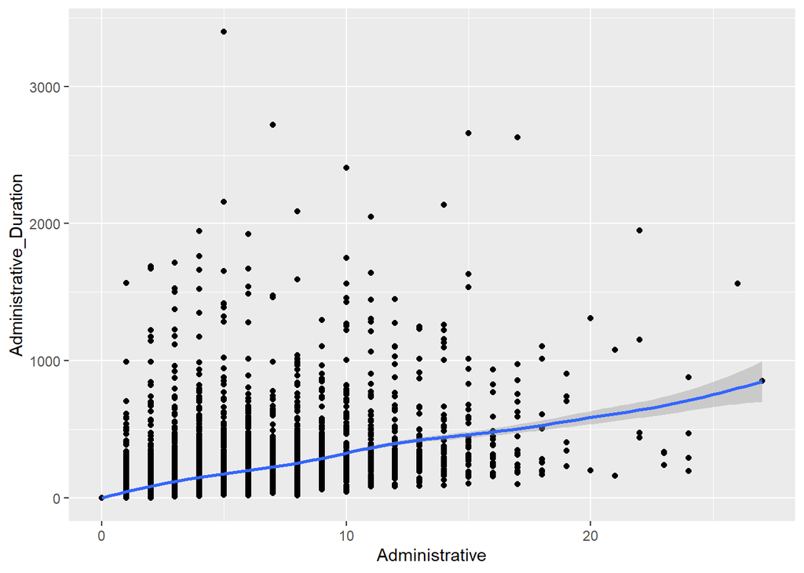

```r
ggplot(df, aes(x=Administrative, y=Administrative_Duration)) +
  geom_point() +
  geom_smooth()
```

There is no strong co-relation between the no. of administrative pages visited and the duration.

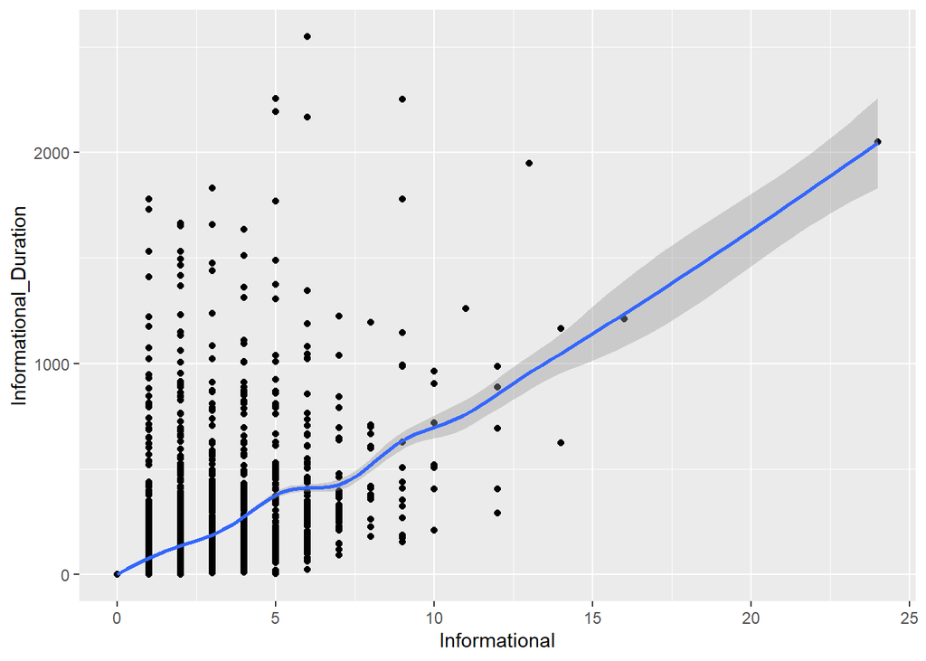

```r
ggplot(df, aes(x=Informational, y=Informational_Duration)) +
  geom_point() +
  geom_smooth()
```

There is no strong co-relation between the no. of informational pages visited and the duration.

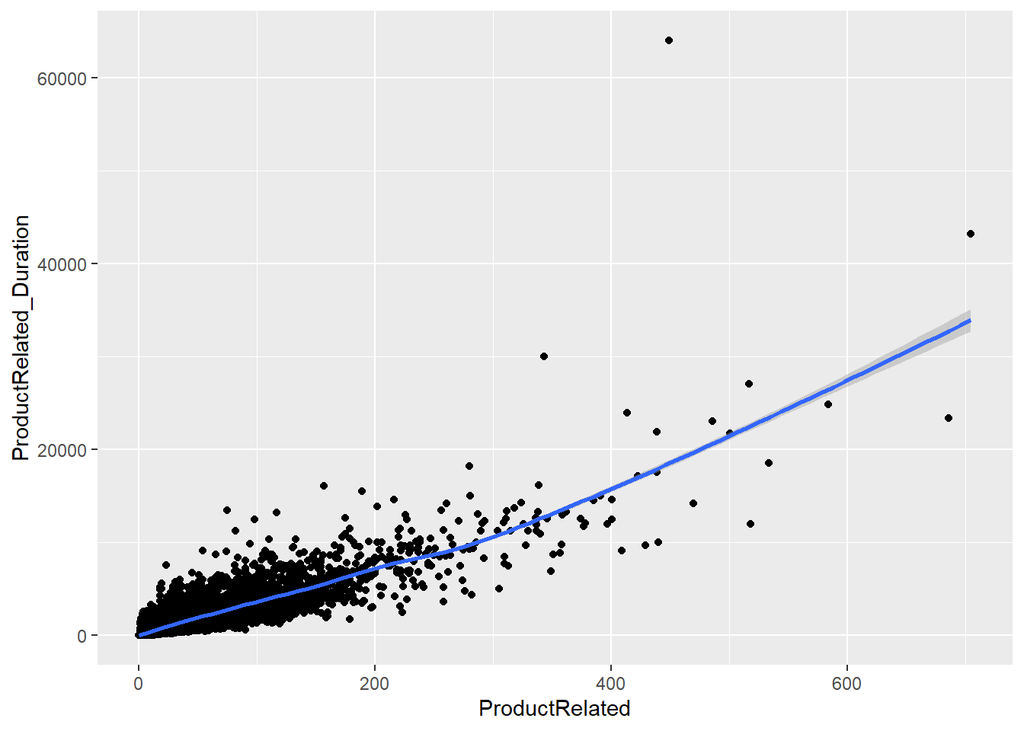

```r
ggplot(df, aes(x=ProductRelated, y=ProductRelated_Duration)) +
  geom_point() +
  geom_smooth()
```

There seems to be a strong co-relation between the no. of product related pages visited and the duration. This may be an important factor where independence of feature is a consideration.

Also, there are some clear outlier points and we may want to perform outlier handling for these points. We will re-plot the smoothening layer without the 2 outliers and check.

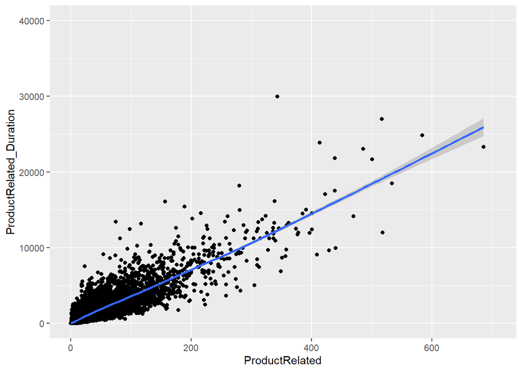

```r
ggplot(df, aes(x=ProductRelated, y=ProductRelated_Duration)) +
  geom_point() +
  geom_smooth() +
  ylim(c(0,40000))
```

Now we can see an almost linear relation between the features.

**Next we will explore the relation of the features Administrative, Informational and ProductRelated count of pages in the session with the Revenue outcome.**

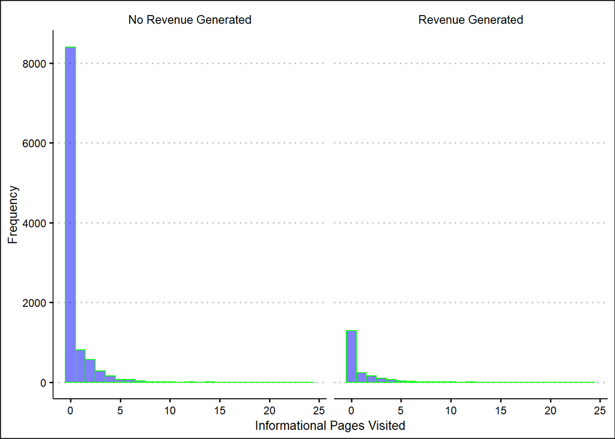

```r
# vector for customizing the label displayed for Revenue
custlabel <- c('TRUE' = "Revenue Generated", 'FALSE' = "No Revenue Generated")

# plotting the frequencies of informational pages per session for both FALSE and TRUE Revenue
ggplot(data = df, mapping = aes(x = Informational)) +
  geom_histogram(binwidth = 1, color='green', fill='blue', alpha=0.5) +
  facet_grid(.~Revenue, labeller=labeller(Revenue = custlabel)) +
  labs(x = 'Informational Pages Visited', y = 'Frequency') +
  theme_clean()
```

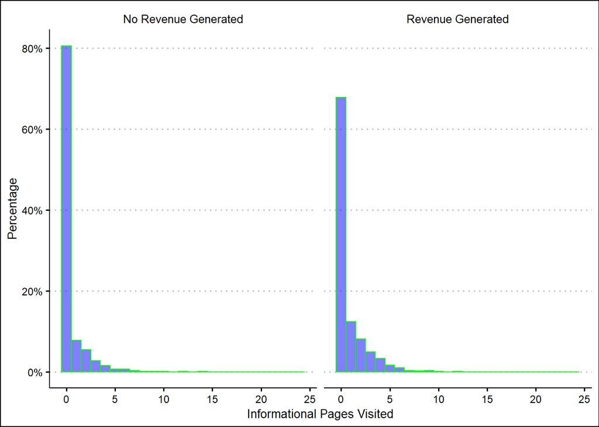

```r
# plotting the frequency distribution as % for informational pages per session for both FALSE and TRUE Revenue. e.g when Revenue is false, 80% of sessions had a zero informational page browsed
ggplot(data = df, mapping = aes(x = Informational)) +
  geom_histogram(binwidth = 1,aes(y = (..count..)/tapply(..count..,..PANEL..,sum)[..PANEL..] ), color='green', fill='blue', alpha=0.5) +
  facet_grid(.~Revenue, labeller=labeller(Revenue = custlabel)) +
  labs(x = 'Informational Pages Visited', y = 'Percentage') +
  scale_y_continuous(labels=scales::percent) +
  theme_clean()
```

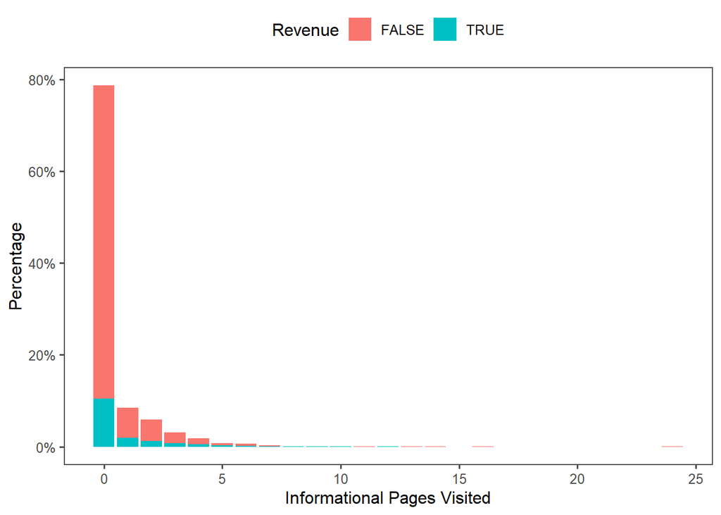

```r
# plotting the merged frequency distribution as % for informational pages per session and showing individual weights of FALSE and TRUE Revenue. e.g ~78% of all sessions had a zero informational page browsed
ggplot(df, aes(x= Informational)) +
  geom_bar(aes(y = (..count..)/sum(..count..), fill = Revenue), stat="count") +
  labs(x = 'Informational Pages Visited', y = 'Percentage') +
  scale_y_continuous(labels = scales::percent) +
  theme_few() +
  theme(legend.position="top")
```

There does not look like any strong correlation with Revenue for informational pages.

Let’s check product related pages.

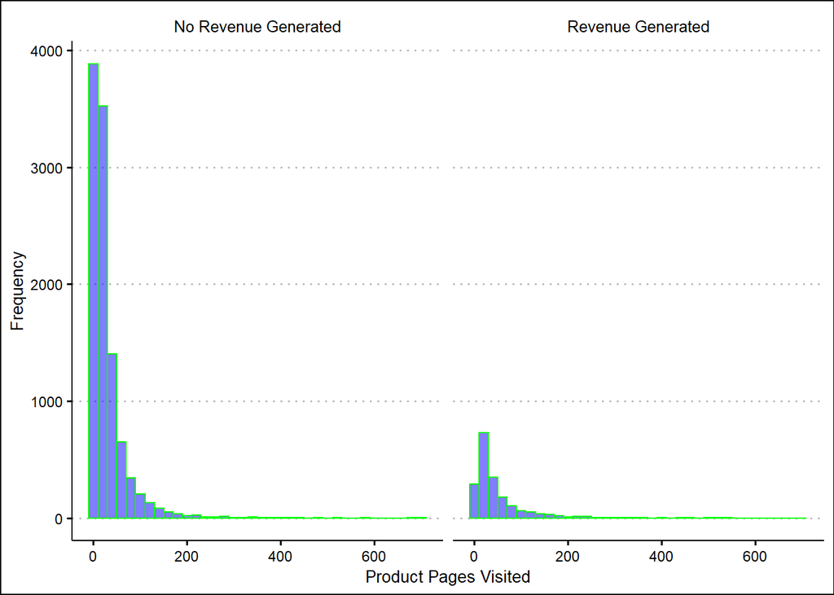

```r
# plotting the frequencies of product related pages per session for both FALSE and TRUE Revenue
ggplot(data = df, mapping = aes(x = ProductRelated)) +
  geom_histogram(binwidth = 20, color='green', fill='blue', alpha=0.5) +
  facet_grid(.~Revenue, labeller=labeller(Revenue = custlabel)) +
  labs(x = 'Product Pages Visited', y = 'Frequency') +
  theme_clean()
```

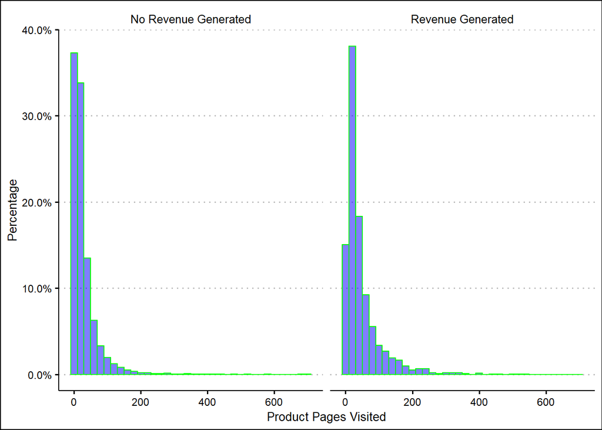

```r
# plotting the frequency distribution as % for product related pages per session for both FALSE and TRUE Revenue.
ggplot(data = df, mapping = aes(x = ProductRelated)) +
  geom_histogram(binwidth = 20,aes(y = (..count..)/tapply(..count..,..PANEL..,sum)[..PANEL..] ), color='green', fill='blue', alpha=0.5) +
  facet_grid(.~Revenue, labeller=labeller(Revenue = custlabel)) +
  labs(x = 'Product Pages Visited', y = 'Percentage') +
  scale_y_continuous(labels=scales::percent) +
  theme_clean()
```

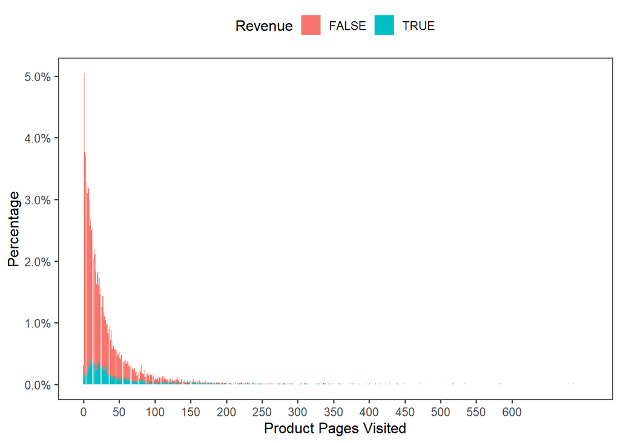

```r
# plotting the merged frequency distribution as % for product related pages per session and showing individual weights of FALSE and TRUE Revenue.
ggplot(df, aes(x= ProductRelated)) +
  geom_bar(aes(y = (..count..)/sum(..count..), fill = Revenue), stat="count") +
  labs(x = 'Product Pages Visited', y = 'Percentage') +
  scale_y_continuous(labels = scales::percent) +
  scale_x_continuous(breaks=seq(0, 600, 50)) +
  theme_few() +
  theme(legend.position="top")
```

There is a strong chance that for revenue generating sessions the no. of product pages visited > 0.

Let’s check administrative pages.

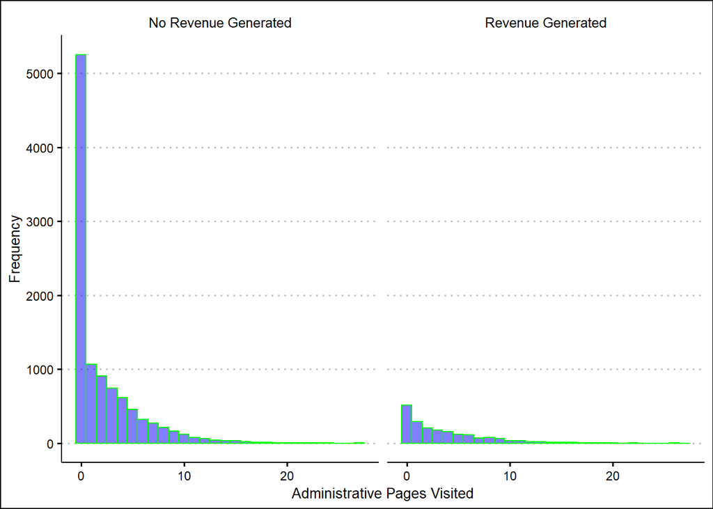

```r
# plotting the frequencies of administrative pages per session for both FALSE and TRUE Revenue
ggplot(data = df, mapping = aes(x = Administrative)) +
  geom_histogram(binwidth = 1, color='green', fill='blue', alpha=0.5) +
  facet_grid(.~Revenue, labeller=labeller(Revenue = custlabel)) +
  labs(x = 'Administrative Pages Visited', y = 'Frequency') +
  theme_clean()
```

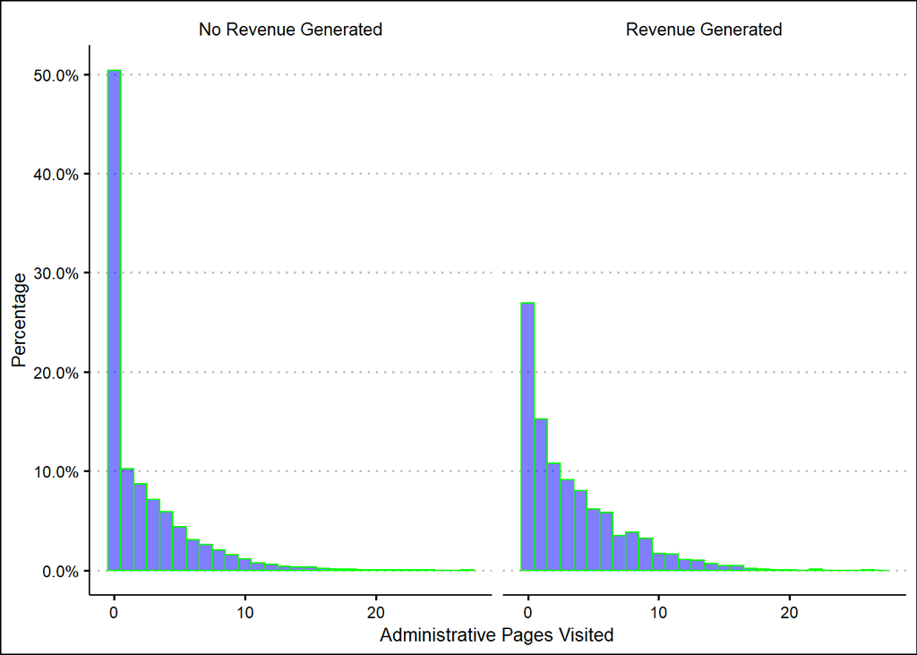

```r
# plotting the frequency distribution as % for administrative pages per session for both FALSE and TRUE Revenue.
ggplot(data = df, mapping = aes(x = Administrative)) +
  geom_histogram(binwidth = 1,aes(y = (..count..)/tapply(..count..,..PANEL..,sum)[..PANEL..] ), color='green', fill='blue', alpha=0.5) +
  facet_grid(.~Revenue, labeller=labeller(Revenue = custlabel)) +
  labs(x = 'Administrative Pages Visited', y = 'Percentage') +
  scale_y_continuous(labels=scales::percent) +
  theme_clean()
```

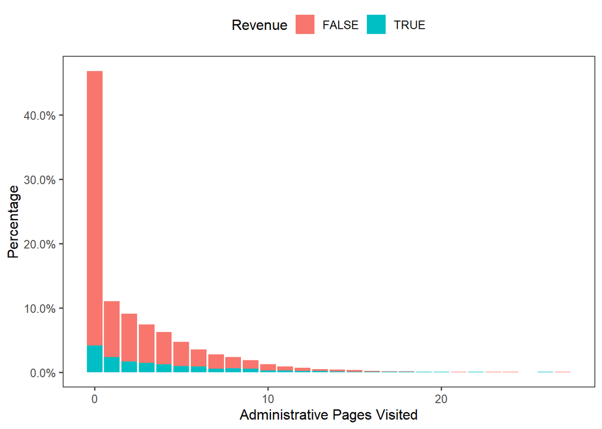

```r
# plotting the merged frequency distribution as % for administrative pages per session and showing individual weights of FALSE and TRUE Revenue.
ggplot(df, aes(x= Administrative)) +
  geom_bar(aes(y = (..count..)/sum(..count..), fill = Revenue), stat="count") +
  labs(x = 'Administrative Pages Visited', y = 'Percentage') +
  scale_y_continuous(labels = scales::percent) +
  theme_few() +
  theme(legend.position="top")
```

There does not look like any strong correlation with Revenue for administrative pages.

**Next we will explore the 3 features - BounceRates, ExitRates and PageValues.**

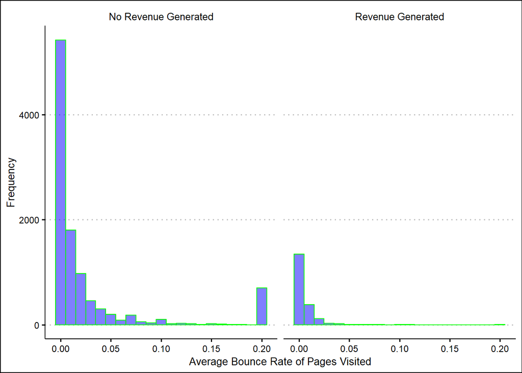

```r
# Frequency distribution of BounceRates over sessions
ggplot(data = df, mapping = aes(x = BounceRates)) +
  geom_histogram(binwidth = 0.01, color='green', fill='blue', alpha=0.5) +
  facet_grid(.~Revenue, labeller=labeller(Revenue = custlabel)) +
  labs(x = 'Average Bounce Rate of Pages Visited', y = 'Frequency') +
  theme_clean()
```

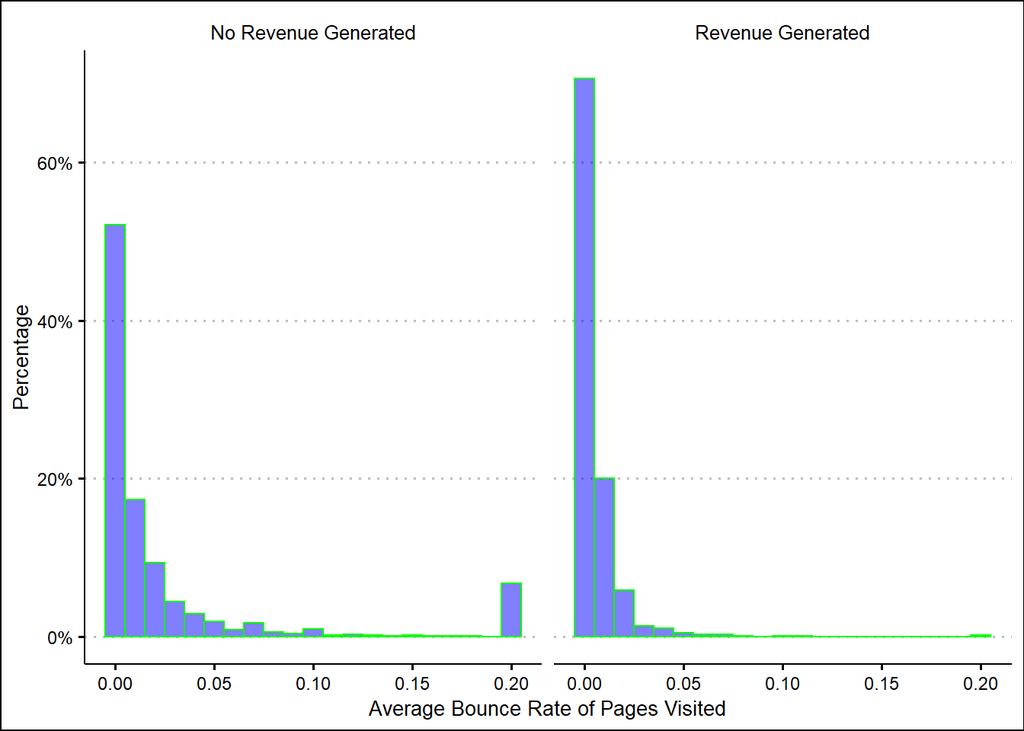

```r
# % of frequency distribution of BounceRates over sessions
ggplot(data = df, mapping = aes(x = BounceRates)) +
  geom_histogram(binwidth = 0.01,aes(y = (..count..)/tapply(..count..,..PANEL..,sum)[..PANEL..] ), color='green', fill='blue', alpha=0.5) +
  facet_grid(.~Revenue, labeller=labeller(Revenue = custlabel)) +
  labs(x = 'Average Bounce Rate of Pages Visited', y = 'Percentage') +
  scale_y_continuous(labels=scales::percent) +
  theme_clean()
```

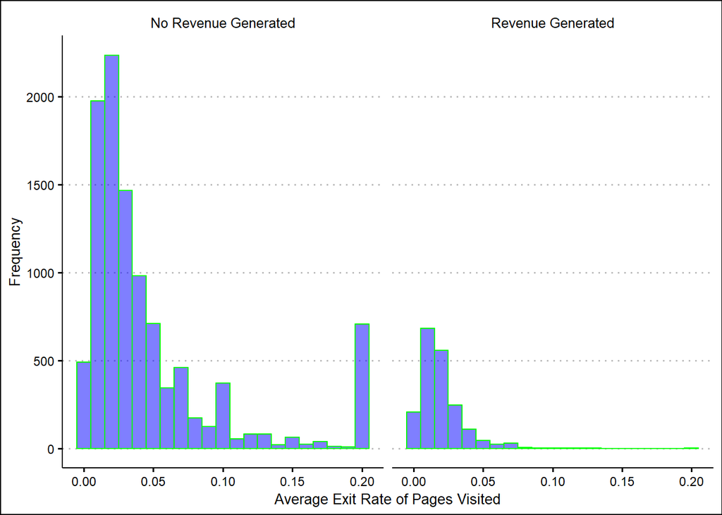

```r
# Frequency distribution of ExitRates over sessions
ggplot(data = df, mapping = aes(x = ExitRates)) +
  geom_histogram(binwidth = 0.01, color='green', fill='blue', alpha=0.5) +
  facet_grid(.~Revenue, labeller=labeller(Revenue = custlabel)) +
  labs(x = 'Average Exit Rate of Pages Visited', y = 'Frequency') +
  theme_clean()
```

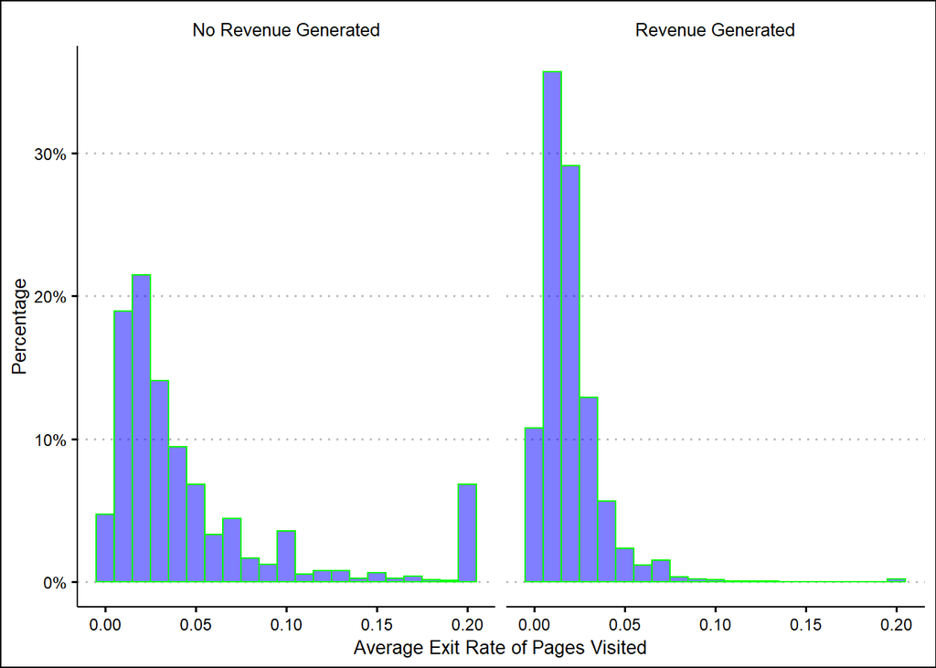

```r
# % of frequency distribution of ExitRates over sessions
ggplot(data = df, mapping = aes(x = ExitRates)) +
  geom_histogram(binwidth = 0.01,aes(y = (..count..)/tapply(..count..,..PANEL..,sum)[..PANEL..] ), color='green', fill='blue', alpha=0.5) +
  facet_grid(.~Revenue, labeller=labeller(Revenue = custlabel)) +
  labs(x = 'Average Exit Rate of Pages Visited', y = 'Percentage') +
  scale_y_continuous(labels=scales::percent) +
  theme_clean()
```

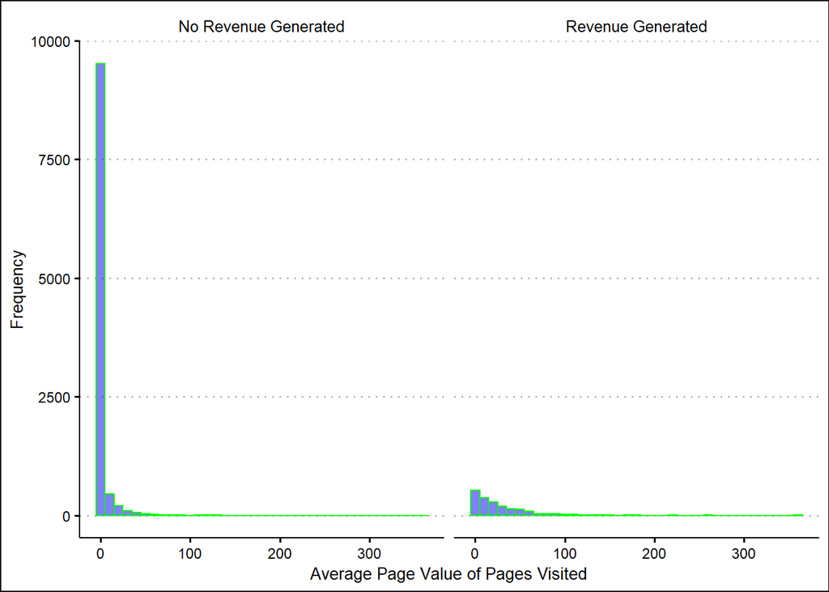

```r
# Frequency distribution of PageValues over sessions
ggplot(data = df, mapping = aes(x = PageValues)) +
  geom_histogram(binwidth = 10, color='green', fill='blue', alpha=0.5) +
  facet_grid(.~Revenue, labeller=labeller(Revenue = custlabel)) +
  labs(x = 'Average Page Value of Pages Visited', y = 'Frequency') +
  theme_clean()
```

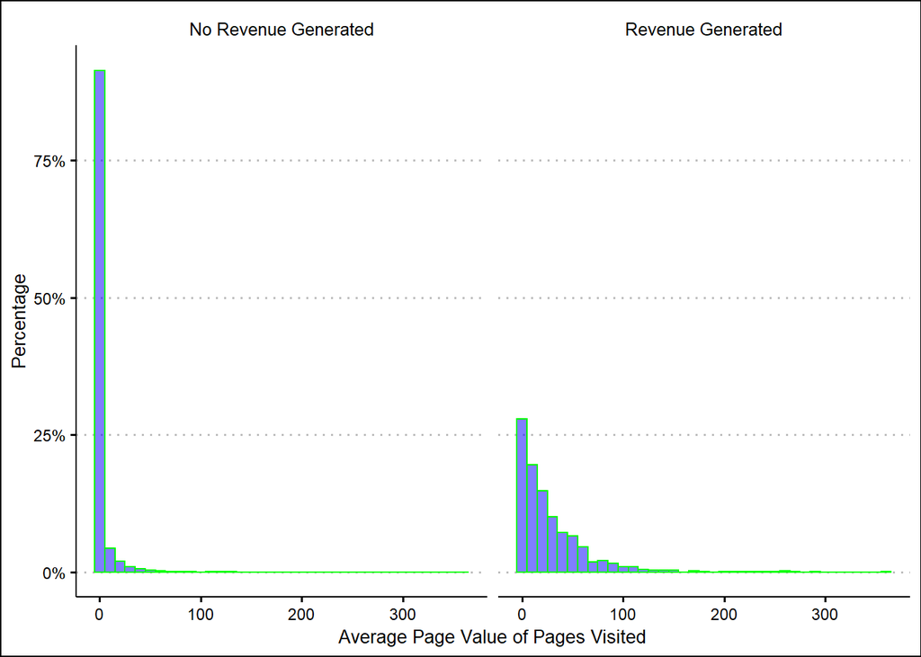

```r
ggplot(data = df, mapping = aes(x = PageValues)) +
  geom_histogram(binwidth = 10,aes(y = (..count..)/tapply(..count..,..PANEL..,sum)[..PANEL..] ), color='green', fill='blue', alpha=0.5) +
  facet_grid(.~Revenue, labeller=labeller(Revenue = custlabel)) +
  labs(x = 'Average Page Value of Pages Visited', y = 'Percentage') +
  scale_y_continuous(labels=scales::percent) +
  theme_clean()
```

Page Values are spread out over a large range but it looks like a good candidate as a categorical feature rather than continuous. So we will do feature engineering to create a new categorical feature - PageValuesCategory from Page Values.

We will bin the new category values as follows: if PageValues = 0 then ‘ZERO’ else if PageValues>0 and PageValues<10 then ‘LOW’ else if PageValues>=10 and PageValues<50 then ‘MEDIUM’ else if PageValues>=50 then ‘HIGH’

```r
# summary of PageValues
summary(df$PageValues)
```

```
##    Min. 1st Qu.  Median    Mean 3rd Qu.    Max.
##   0.000   0.000   0.000   5.889   0.000 361.764
```

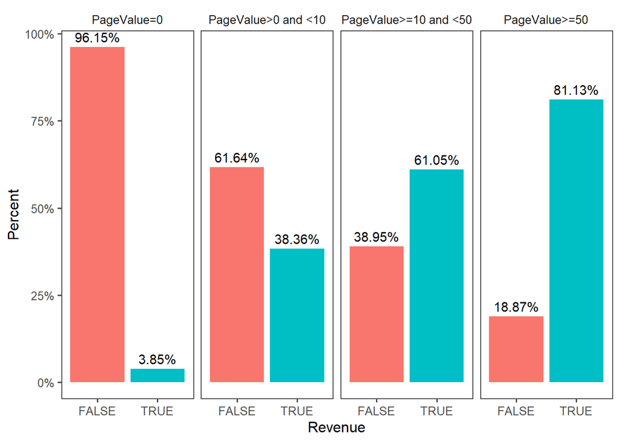

```r
# new categorical feature
df$PageValuesCategory[df$PageValues==0]<-'ZERO'
df$PageValuesCategory[df$PageValues>0 & df$PageValues<10]<-'LOW'
df$PageValuesCategory[df$PageValues>=10 & df$PageValues<50]<-'MEDIUM'
df$PageValuesCategory[df$PageValues>=50]<-'HIGH'

# vector for customized label in plot
custlabel2 <- c('ZERO' = "PageValue=0", 'LOW' = "PageValue>0 and <10", 'MEDIUM' = "PageValue>=10 and <50", 'HIGH' = "PageValue>=50")

# for customized ordering of label in plot
df$PageValuesCategoryOrdered <- factor(df$PageValuesCategory, levels = c('ZERO','LOW','MEDIUM','HIGH'))

# plot of page value distribution % against the binned feature
ggplot(df, aes(x= Revenue, group=PageValuesCategory)) +
  geom_bar(aes(y = ..prop.., fill = factor(..x..)), stat="count", show.legend = FALSE) +
  geom_text(aes( label = scales::percent(..prop..),
                 y= ..prop.. ), stat= "count", vjust = -.5) +
  labs(y = "Percent") +
  facet_grid(~PageValuesCategoryOrdered, labeller=labeller(PageValuesCategoryOrdered = custlabel2)) +
  scale_y_continuous(labels = scales::percent) +
  theme_few()
```

As seen in the plot there seems to be a very strong correlation between the categorized page value feature and Revenue target. e.g page value of zero has a false revenue of 96% and page value > 50 has 81% true revenue.

**Now let’s look at rest of the features**

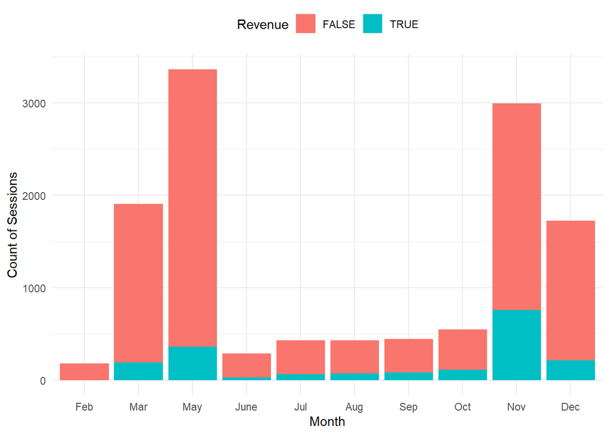

```r
# factoring for customized sort order
df$Month <- factor(df$Month, levels = c('Jan','Feb','Mar','Apr','May','June','Jul','Aug','Sep','Oct','Nov','Dec'))

# frequency plot of sessions against Month indicating Revenue
ggplot(df, aes(x= Month)) +
  geom_bar(aes(y = (..count..), fill = Revenue), stat="count") +
  labs(x = 'Month', y = 'Count of Sessions') +
  theme_minimal() +
  theme(legend.position="top")
```

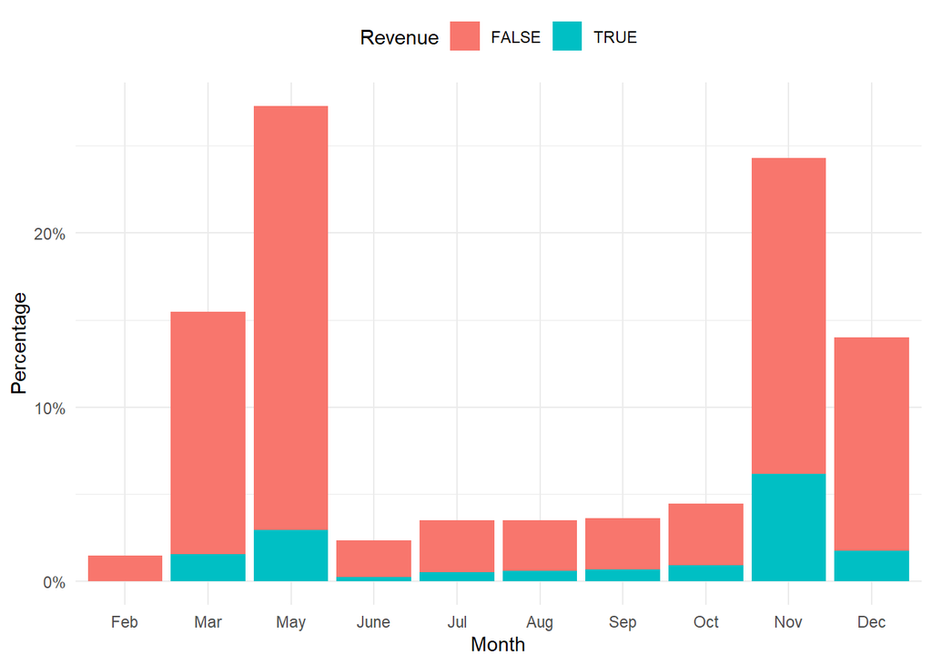

```r
# % plot of sessions against Month indicating Revenue
ggplot(df, aes(x= Month)) +
  geom_bar(aes(y = (..count..)/sum(..count..), fill = Revenue), stat="count") +
  labs(x = 'Month', y = 'Percentage') +
  scale_y_continuous(labels = scales::percent) +
  theme_minimal() +
  theme(legend.position="top")
```

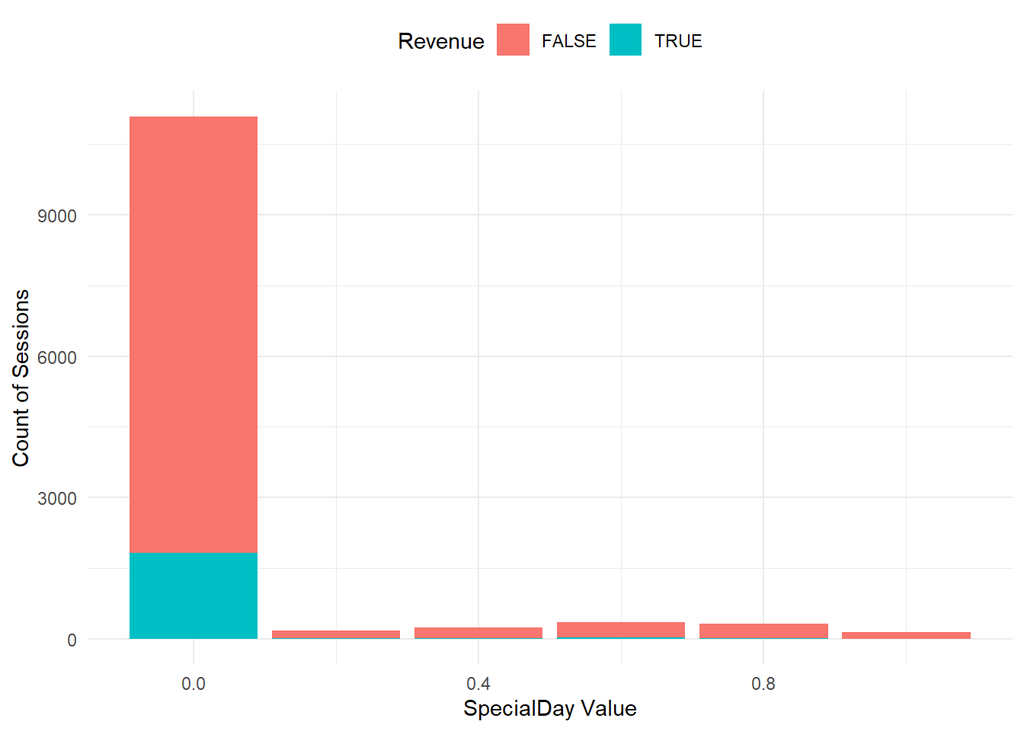

```r
# frequency plot against SpecialDay which includes regular days with value 0
ggplot(df, aes(x= SpecialDay)) +
  geom_bar(aes(y = (..count..), fill = Revenue), stat="count") +
  labs(x = 'SpecialDay Value', y = 'Count of Sessions') +
  theme_minimal() +
  theme(legend.position="top")
```

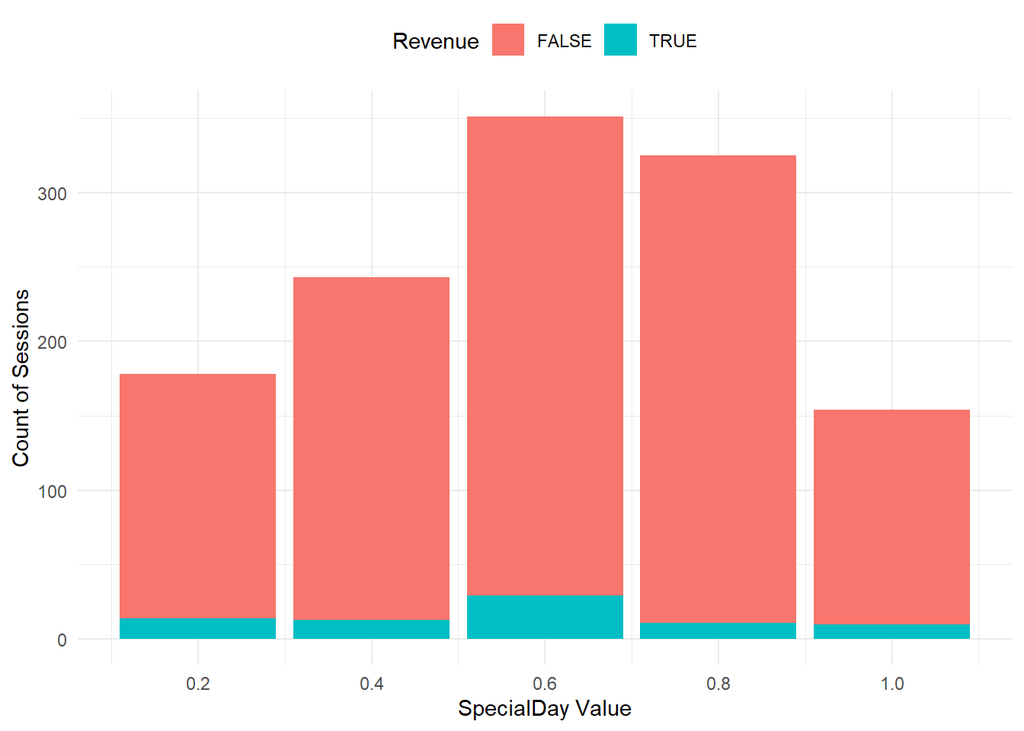

```r
# frequency plot against SpecialDay for only values>0 for detailed analysis
ggplot(df[df$SpecialDay>0,], aes(x= SpecialDay)) +
  geom_bar(aes(y = (..count..), fill = Revenue), stat="count") +
  labs(x = 'SpecialDay Value', y = 'Count of Sessions') +
  scale_x_continuous(breaks=seq(0, 1, .2)) +
  theme_minimal() +
  theme(legend.position="top")
```

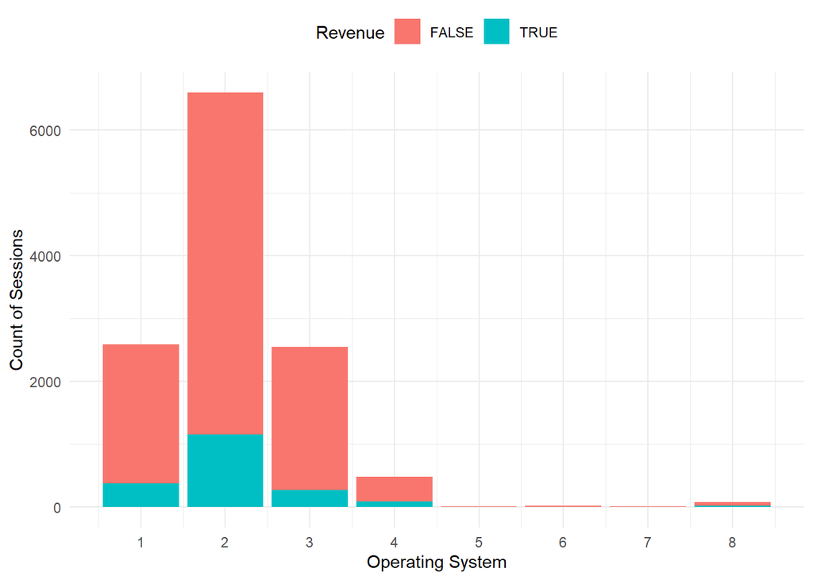

```r
# frequency plot against OperatingSystems
ggplot(df, aes(x= OperatingSystems)) +
  geom_bar(aes(y = (..count..), fill = Revenue), stat="count") +
  labs(x = 'Operating System', y = 'Count of Sessions') +
  scale_x_continuous(breaks=seq(0, 8, 1)) +
  theme_minimal() +
  theme(legend.position="top")
```

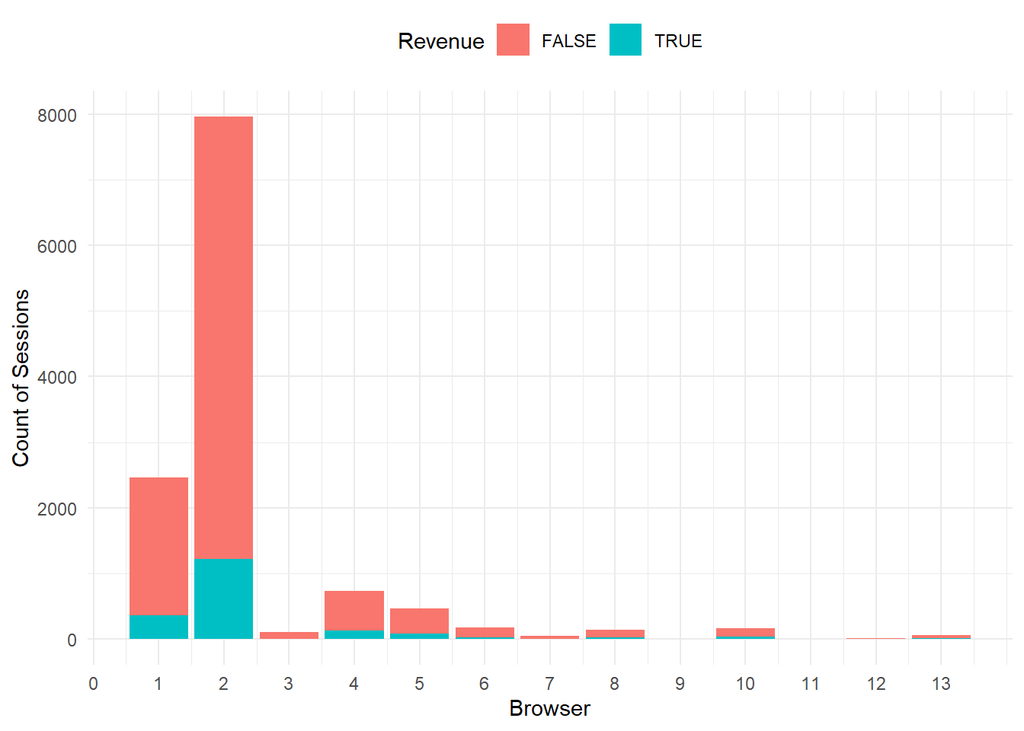

```r
# frequency plot against Browser
ggplot(df, aes(x= Browser)) +
  geom_bar(aes(y = (..count..), fill = Revenue), stat="count") +
  labs(x = 'Browser', y = 'Count of Sessions') +
  scale_x_continuous(breaks=seq(0, 13, 1)) +
  theme_minimal() +
  theme(legend.position="top")
```

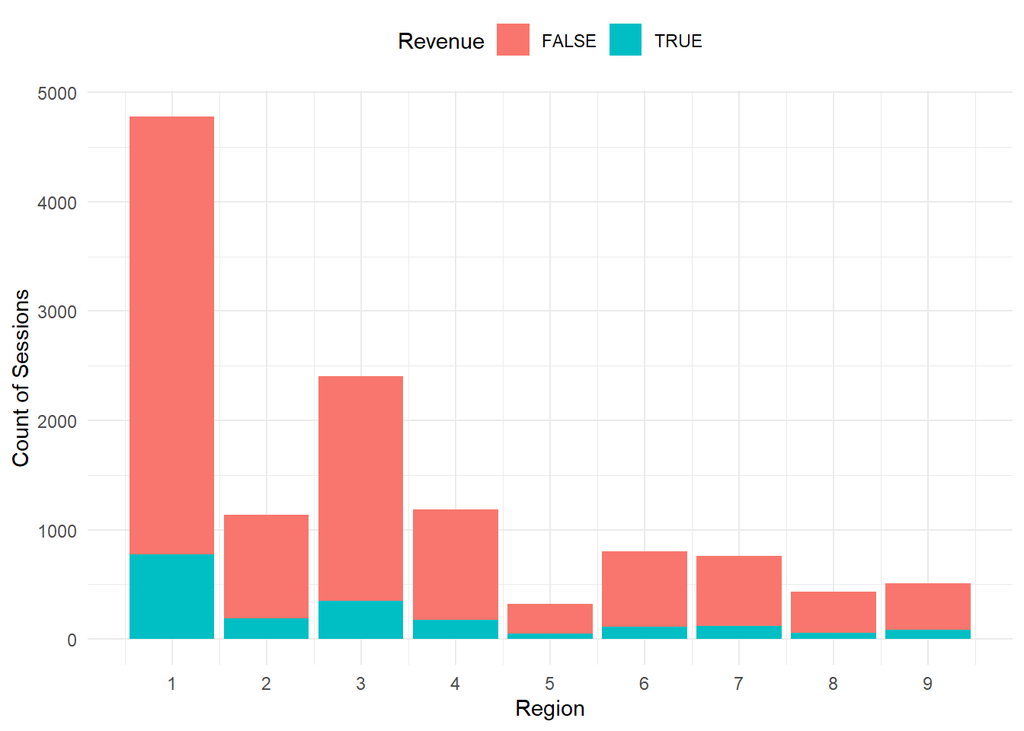

```r
# frequency plot against Region
ggplot(df, aes(x= Region)) +
  geom_bar(aes(y = (..count..), fill = Revenue), stat="count") +
  labs(x = 'Region', y = 'Count of Sessions') +
  scale_x_continuous(breaks=seq(0, 10, 1)) +
  theme_minimal() +
  theme(legend.position="top")
```

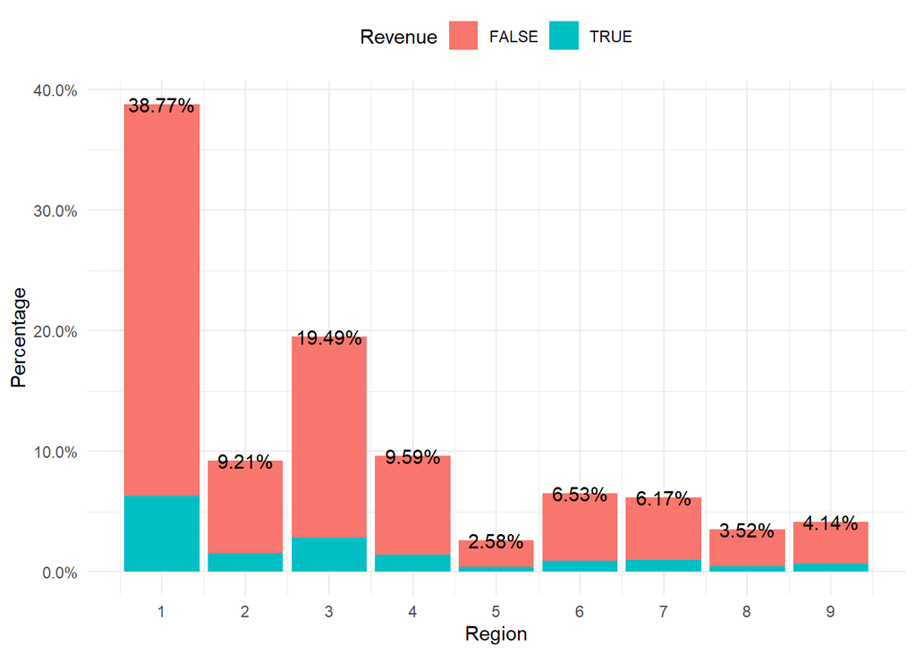

```r
# % of frequency plot against Region for better analysis
ggplot(df, aes(x= Region)) +
  geom_bar(aes(y = (..count..)/sum(..count..), fill = Revenue), stat="count") +
  geom_text(aes( label = scales::percent(..prop..),
                 y= ..prop.. ), stat= "count") +
  labs(x = 'Region', y = 'Percentage') +
  scale_x_continuous(breaks=seq(0, 10, 1)) +
  scale_y_continuous(labels = scales::percent) +
  theme_minimal() +
  theme(legend.position="top")
```

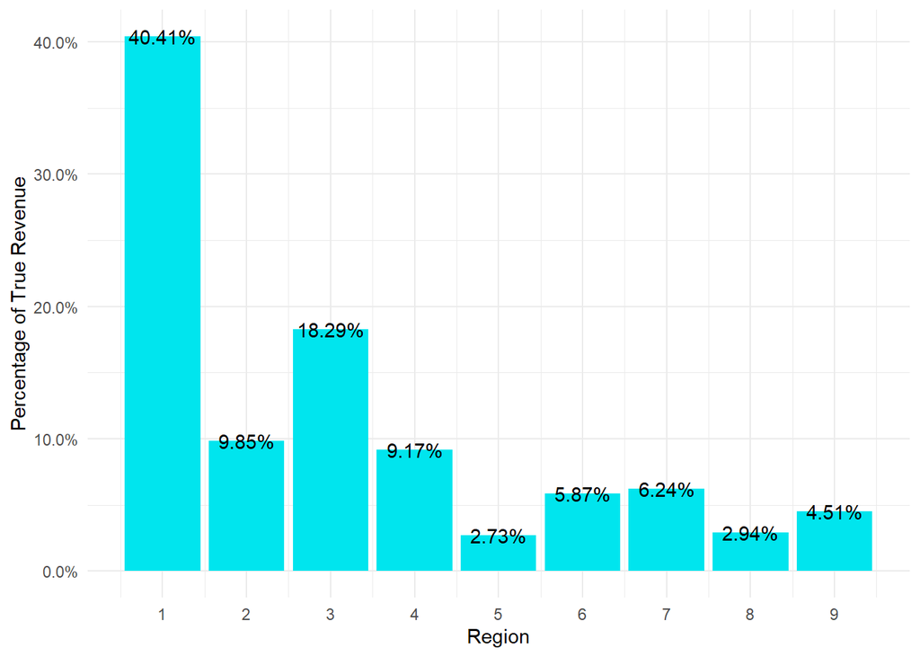

```r
# % of frequency plot against Region for TRUE Revenue sessions
ggplot(df[df$Revenue==TRUE,], aes(x= Region)) +
  geom_bar(aes(y = (..count..)/sum(..count..)), fill = 'turquoise2', stat="count") +
  geom_text(aes( label = scales::percent(..prop..),
                 y= ..prop.. ), stat= "count") +
  labs(x = 'Region', y = 'Percentage of True Revenue') +
  scale_x_continuous(breaks=seq(0, 10, 1)) +
  scale_y_continuous(labels = scales::percent) +
  theme_minimal() +
  theme(legend.position="top")
```

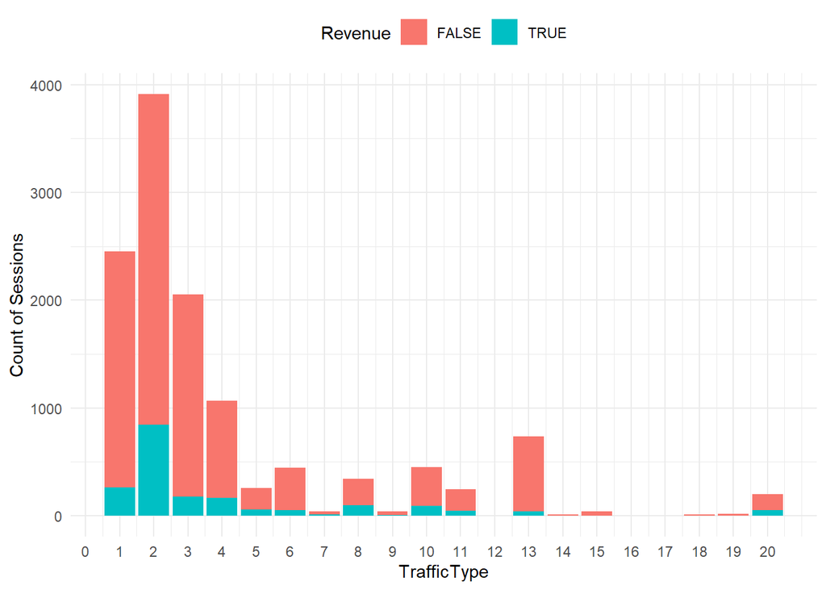

```r
# frequency plot against TrafficType
ggplot(df, aes(x= TrafficType)) +
  geom_bar(aes(y = (..count..), fill = Revenue), stat="count") +
  labs(x = 'TrafficType', y = 'Count of Sessions') +
  scale_x_continuous(breaks=seq(0, 20, 1)) +
  theme_minimal() +
  theme(legend.position="top")
```

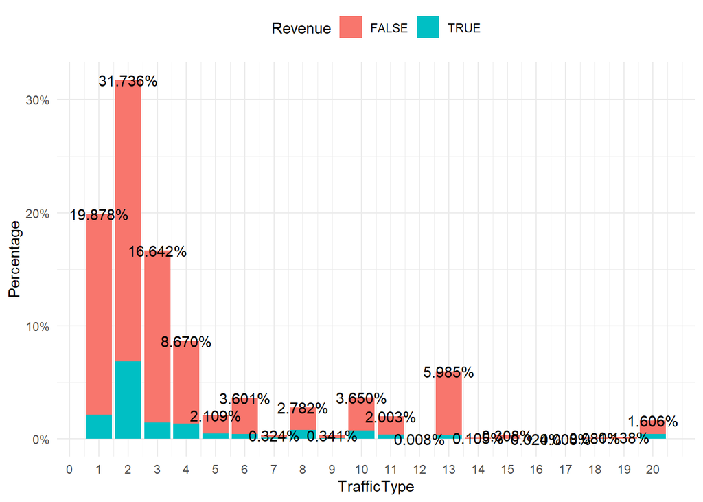

```r
# % of frequency plot against TrafficType for better analysis
ggplot(df, aes(x= TrafficType)) +
  geom_bar(aes(y = (..count..)/sum(..count..), fill = Revenue), stat="count") +
  geom_text(aes( label = scales::percent(..prop..),
                 y= ..prop.. ), stat= "count") +
  labs(x = 'TrafficType', y = 'Percentage') +
  scale_x_continuous(breaks=seq(0, 20, 1)) +
  scale_y_continuous(labels = scales::percent) +
  theme_minimal() +
  theme(legend.position="top")
```

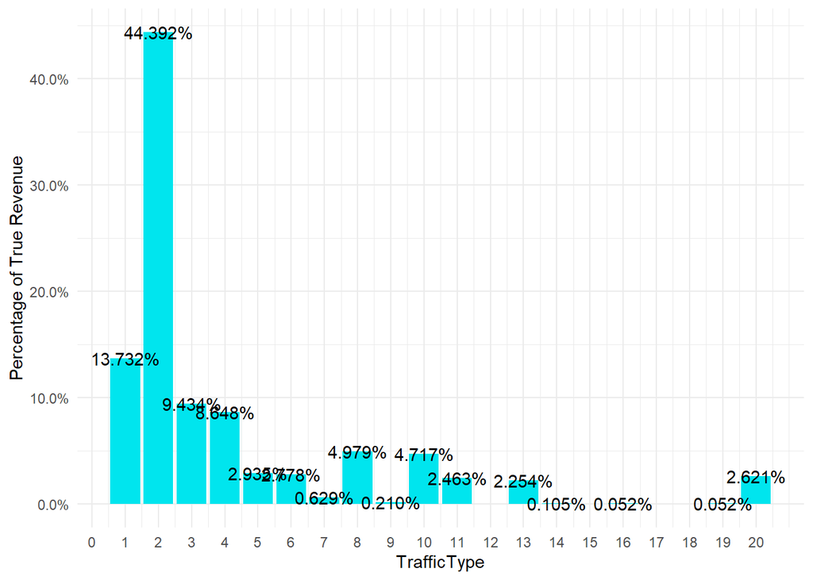

```r
# % of frequency plot against TrafficType for TRUE Revenue sessions
ggplot(df[df$Revenue==TRUE,], aes(x= TrafficType)) +
  geom_bar(aes(y = (..count..)/sum(..count..)), fill = 'turquoise2', stat="count") +
  geom_text(aes( label = scales::percent(..prop..),
                 y= ..prop.. ), stat= "count") +
  labs(x = 'TrafficType', y = 'Percentage of True Revenue') +
  scale_x_continuous(breaks=seq(0, 20, 1)) +
  scale_y_continuous(labels = scales::percent) +
  theme_minimal() +
  theme(legend.position="top")
```